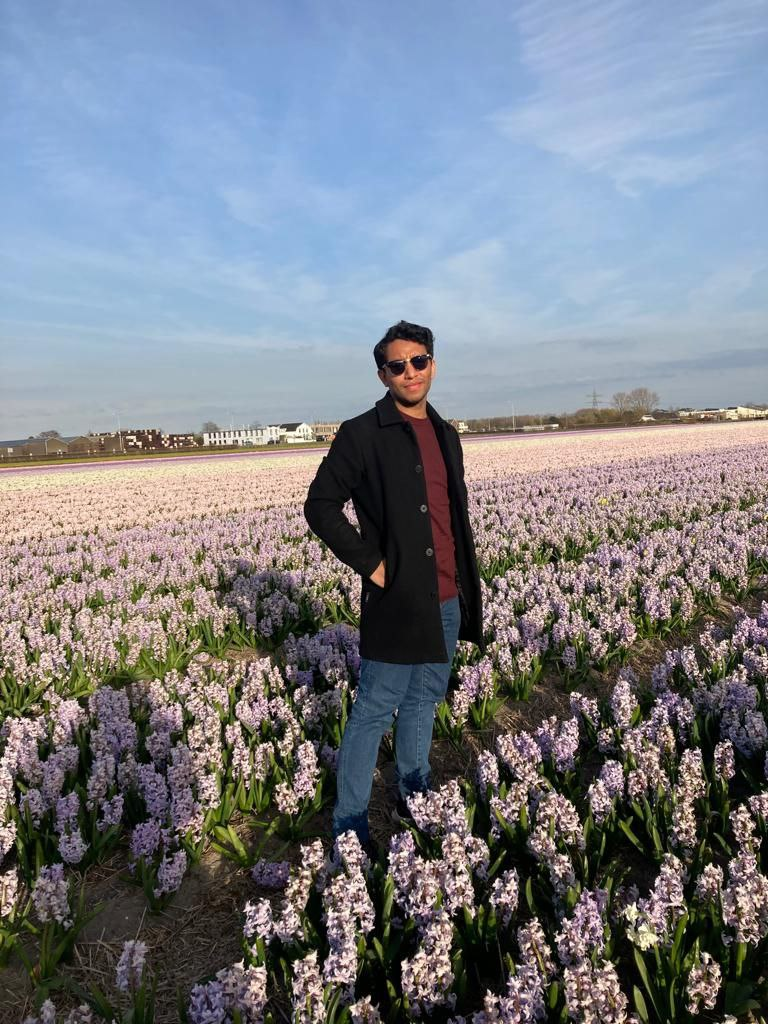

# About me

I am a Bayesian Data scientist with a strong background in Bayesian theory, probabilistic programming, time-series analysis, actuarial science, risk modeling, mathematical decision-making, and package developing in `R`.

`Keywords:` *Forecasting, Bayesian data analyst, Time-series, Probabilistic ML, Mathematics*.

### Skills

- `Programming`: *R, Python, Julia, Octave, Matlab, C++, SQL, Git*.
- `Statistical tools`: *SPSS, STATA, R, Excel, Stan, PyMC, Tableau, PowerBI.*
- `Languagues`: *Spanish (native), English (professional), Dutch (Beginner)*.

## Research projects

- [Bayesian order identification of ARMA models with projection predictive inference](https://arxiv.org/abs/2208.14824). *McLatchie Y., Alonzo Matamoros A., Vehtari A. (2022).* In submission to AISTATS 2023.
- [Uncertainty in Bayesian Leave-One-Out Cross-Validation Based Model Comparison](https://arxiv.org/abs/2008.10296). *Sivula T., Magnusson M., Alonzo Matamoros A., Vehtari A. (2022).* Submitted to JMLR.
- [The Multiple Degrees of freedom Gaussian Process](https://bisp12.imati.cnr.it/virtual_poster.php?ref_code=BISP12). *Alonzo Matamoros A. (2021).* Presented at the Workshop of Bayesian Stochastic Processes.
- [Bayesian time-series modeling with bayesforecast](https://cran.r-project.org/web/packages/bayesforecast/index.html). *Alonzo Matamoros A., Vehtari A. (2021).* Presented at the International Society of Bayesian Analysis 2021.
- [An R package for Normality in Stationary Processes](https://arxiv.org/abs/2009.10481). *Alonzo Matamoros A, Nieto-Reyes A. (2020)*. Submitted to Journal of R.

## Education

### Ph.D. candidate in Computer Science.

*Aalto University, Finland | October 2020*.

### M.Sc. in Mathematics and Computer Science.

*Universidad de Cantabria, Spain | October 2019 - October 2020*.

### Certification in Probability.

*Society of Actuaries, U.S.A. | November 2016*.

### B. Sc. in Mathematics and Computer Science.

*Universidad Nacional Autonoma de Honduras | October 2010 - October 2015*.

## Experience

### Research contract

*Finnish Center of Artificial Intelligence | October 2020.*

Studied the uncertainty of Cross-Validation methods when comparing probabilistic machine learning models. Proposed an algorithm for automatic forecasting with probabilistic time-series models.

**Skills**: `R, Python, ML, Model Comparison, Data Visualization.`.

### Assistant Professor, Statistics Department

*Universidad Nacional Autonoma de Honduras (UNAH) | October 2017 – October 2020.*

Imparted Statistical Inference, Stochastic Processes, and Linear Models classes for the department of Statistics.

**Skills**: `Julia, STATA, Mathematics, Bayesian Statistics`.

### Data analyst

*Instituto Hondureño de Transporte Público | January 2017 – April 2018.*

Designed statistical models for estimating the public transport demands using simulation and stochastic processes. Adapted dynamic econometric models to analyze Tegucigalpa, Honduras’s public transport system.

**Skills**: `Simulation, Probability, Mathematical Modeling, Bayesian Statistics`.

### Actuarial analyst

*Instituto Hondureño de Seguridad Social | January 2016 – January 2017.*

Wrote scripts for data cleaning and summaries for the actuarial evaluation of the total of affiliates in Honduras’ primary pension system. Created big-data modules for the actuarial analysis of the pension system.

**Skills**:`SQL, Data-cleaning, Big-data, Actuarial Modeling`.

### Statistical Consultant

*Instituto Hondureño de Turismo | January 2015 – January 2016.*

Designed the Sampling procedure for estimating the Touristic Expenditure in Honduras. I implemented time-series models for analyzing the principal financial indicators related to tourism.

**Skills**: `SPSS, Excell, forecasting, time-series`.